# Fairfax Schools, VA, USA

Cassandra Sperow

6/2/2022

## Fairfax County, VA DOE SOL School Test Scores

This analysis file is for my own curiosity in reviewing how schools in Fairfax County, VA performed pre- and post-pandemic for Grade 3 pass rates for English: Reading and Mathematics tests.

It does not seek to judge schools or address school ratings because there are too many other factors that go into what makes a good school.

## Original public data source:

[Virginia Department of Education SOL Test Results](https://www.doe.virginia.gov/statistics_reports/sol-pass-rates/index.shtml)

### Import Libraries

```r
library(tidyverse)
```

### Import Data

```r
schools <- read_csv("../data/2020-2021-school-test-by-test.csv", skip =2)
schools %>% glimpse()
```

```
## Rows: 14,381
## Columns: 17
## $ LEVEL                     <chr> "SCH", "SCH", "SCH", "SCH", "SCH", "SCH", "S…
## $ `Div Num`                 <dbl> 1, 1, 1, 1, 1, 1, 1, 1, 1, 1, 1, 1, 1, 1, 1,…
## $ `Div Name`                <chr> "Accomack County", "Accomack County", "Accom…
## $ `Sch Num`                 <dbl> 701, 701, 701, 701, 701, 701, 701, 540, 540,…
## $ `Sch Name`                <chr> "Accawmacke Elementary", "Accawmacke Element…
## $ `Sch Type`                <chr> "Elem", "Elem", "Elem", "Elem", "Elem", "Ele…
## $ `Low Grade`               <chr> "PK", "PK", "PK", "PK", "PK", "PK", "PK", "9…
## $ `High Grade`              <dbl> 5, 5, 5, 5, 5, 5, 5, 12, 12, 12, 12, 12, 12,…
## $ Subject                   <chr> "English: Reading", "English: Reading", "Eng…
## $ Grade                     <chr> "Gr 3", "Gr 4", "Gr 5", "Gr 3", "Gr 4", "Gr …
## $ Test                      <chr> "English Reading", "English Reading", "Engli…
## $ `2018-2019 Pass Rate`     <chr> "57", "74", "60", "73", "80", "84", "79", "8…
## $ `2019-2020 Pass Rate`     <lgl> NA, NA, NA, NA, NA, NA, NA, NA, NA, NA, NA, …
## $ `2020-2021 Pass Rate`     <chr> "50", "56", "45", "38", "28", "34", "34", "7…
## $ `2018-2019 Adv Pass Rate` <chr> "12", "10", "15", "10", "10", "12", "20", "5…
## $ `2019-2020 Adv Pass Rate` <lgl> NA, NA, NA, NA, NA, NA, NA, NA, NA, NA, NA, …
## $ `2020-2021 Adv Pass Rate` <chr> "3", "6", "7", "3", "4", "3", "6", "13", "0"…
```

### Review of import problems

```r
# problem with parsing due to "<" entered into some fields of data
# Reviewing the original data file, there are indeed these little carats for some pass rates
schools$`2018-2019 Pass Rate` %>% unique()
```

```
##  [1] "57"  "74"  "60"  "73"  "80"  "84"  "79"  "78"  "96"  "77"  "72"  "64"
## [13] "69"  "65"  "81"  "100" "85"  "76"  "92"  "93"  "94"  "86"  "82"  "89"
## [25] "88"  "91"  "<"   "55"  "62"  "44"  "54"  "67"  "58"  "61"  "90"  "83"
## [37] "71"  "70"  "68"  "75"  "50"  "42"  "33"  "87"  "66"  NA    "52"  "99"
## [49] "97"  "98"  "48"  "63"  "59"  "95"  "53"  "47"  "56"  "6"   "35"  "51"
## [61] "43"  "49"  "45"  "40"  "46"  "32"  "26"  "29"  "39"  "41"  "11"  "30"
## [73] "10"  "34"  "27"  "22"  "25"  "38"  "23"  "13"  "19"  "14"  "28"  "8"
## [85] "15"  "37"  "21"  "20"  "36"  "31"  "18"  "24"  "17"
```

```r
schools$`2018-2019 Pass Rate` %>% typeof()
```

```
## [1] "character"
```

```r
schools %>% filter(`2018-2019 Pass Rate`=="<")
```

```
## # A tibble: 321 × 17
##    LEVEL `Div Num` `Div Name`      `Sch Num` `Sch Name`   `Sch Type` `Low Grade`
##    <chr>     <dbl> <chr>               <dbl> <chr>        <chr>      <chr>
##  1 SCH           1 Accomack County       580 Chincoteagu… Combined   6
##  2 SCH           1 Accomack County       530 Tangier Com… Combined   KG
##  3 SCH           1 Accomack County       530 Tangier Com… Combined   KG
##  4 SCH           1 Accomack County       530 Tangier Com… Combined   KG
##  5 SCH           1 Accomack County       530 Tangier Com… Combined   KG
##  6 SCH           1 Accomack County       530 Tangier Com… Combined   KG
##  7 SCH           1 Accomack County       530 Tangier Com… Combined   KG
##  8 SCH           1 Accomack County       530 Tangier Com… Combined   KG
##  9 SCH           1 Accomack County       530 Tangier Com… Combined   KG
## 10 SCH           1 Accomack County       530 Tangier Com… Combined   KG
## # … with 311 more rows, and 10 more variables: `High Grade` <dbl>,
## #   Subject <chr>, Grade <chr>, Test <chr>, `2018-2019 Pass Rate` <chr>,
## #   `2019-2020 Pass Rate` <lgl>, `2020-2021 Pass Rate` <chr>,
## #   `2018-2019 Adv Pass Rate` <chr>, `2019-2020 Adv Pass Rate` <lgl>,
## #   `2020-2021 Adv Pass Rate` <chr>
```

### Setting import to include “<” as an NA value to fix problems from previous import

```r
# checking unique values for the column 'Sch Type'
unique(schools$`Sch Type`)
```

```
## [1] "Elem"     "High"     "Middle"   "Combined"
```

```r
# setting the NA values to include "<" because there was not a value given or key for what the "<" indicates
schools %>%
  mutate(sch_type = parse_factor(`Sch Type`)) %>%
  mutate(pass_rate_18_19 = parse_integer(`2018-2019 Pass Rate`, na = c("", "NA", NA, "<"), trim_ws = TRUE),
         pass_rate_20_21 = parse_integer(`2020-2021 Pass Rate`, na = c("", "NA", NA, "<"), trim_ws = TRUE),
         county = `Div Name`) -> schools
```

# Filtering Data to Focus on Grade 3 Test Scores and Calculating a Percent Change from Pre-Pandemic

```r
schools %>%
  select(county, sch_type, `Sch Name`, Test, Grade, pass_rate_18_19, pass_rate_20_21) %>%
  filter(county=="Fairfax County") %>%
  filter(sch_type=="Elem") %>%
  filter(Grade=="Gr 3") %>%
  mutate(point_diff =  pass_rate_20_21 - pass_rate_18_19) %>%
  mutate(pct_change = (point_diff/pass_rate_18_19)*100) %>%
  mutate(Test = parse_factor(Test)) -> fair_elem_gr3_test_scores

fair_elem_gr3_test_scores %>%
  #schools with pass rate of at least 80
  filter(pass_rate_20_21 >=80) %>% #glimpse()
  # schools that did not go down more than 5 % after covid closures
  filter(pct_change>=-5) -> fair_5schools
```

### How do the pass rates relate to the percent change in test scores post-pandemic?

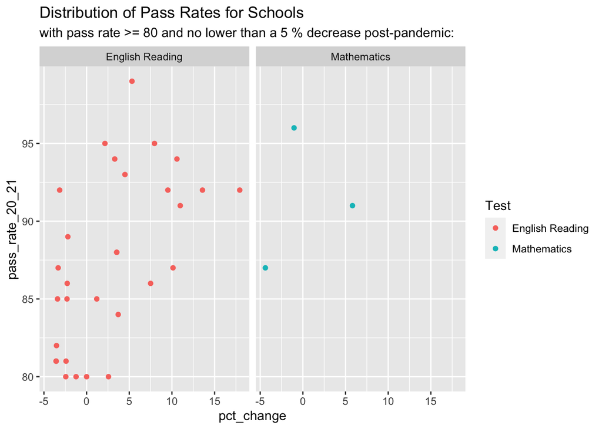

```r
fair_5schools %>%
  arrange(-pct_change) %>%
  ggplot(aes(x = pct_change, y = pass_rate_20_21, color = Test, fill = Test)) +
  geom_point() +
  facet_wrap(~Test) +
  ggtitle("Distribution of Pass Rates for Schools", subtitle = "with pass rate >= 80 and no lower than a 5 % decrease post-pandemic:")
```

Interpretation: - When test scores went up, they went up more for English: Reading than for Math. - Schools that did not go down more than 5% (or that increased test scores at any level) had these things happen more so for English than in Math. - Could this indicate that maybe it was easier for families to focus on reading during school closures than math? - Could this be why there are not as many of the same increases in math scores as students returned after school closures?

### Top 10 Fairfax ELementary Schools with pass rate in ’20-’21 of more than 80 and that also have a percent change of not less than -5%:

- This list shows that the gains during the pandemic seem to be more in English than Math, which is also in the plot above showing more points for English scores than Math scores that fit the criteria of being above 80 and also not having fallen more than 5%

```r
fair_5schools %>%
  slice_max(pass_rate_20_21, n = 10, with_ties = TRUE) %>%
  summarise(`Sch Name`, Test, pass_rate_20_21, pct_change)
```

```
## # A tibble: 11 × 4
##    `Sch Name`                  Test            pass_rate_20_21 pct_change
##    <chr>                       <fct>                     <int>      <dbl>
##  1 Haycock Elementary          English Reading              99       5.32
##  2 Haycock Elementary          Mathematics                  96      -1.03
##  3 Poplar Tree Elementary      English Reading              95       2.15
##  4 Navy Elementary             English Reading              95       7.95
##  5 Colvin Run Elementary       English Reading              94       3.30
##  6 Westbriar Elementary        English Reading              94      10.6
##  7 Kent Gardens Elementary     English Reading              93       4.49
##  8 Sangster Elementary         English Reading              92      -3.16
##  9 Cherry Run Elementary       English Reading              92       9.52
## 10 Vienna Elementary           English Reading              92      13.6
## 11 West Springfield Elementary English Reading              92      17.9
```

```r
# to get the top 10 for English only
fair_elem_gr3_test_scores %>%
  filter(Test=="English Reading") %>%
  slice_max(pct_change, n=10) %>%
  summarise(`Sch Name`)
```

```
## # A tibble: 10 × 1
##    `Sch Name`
##    <chr>
##  1 Cunningham Park Elementary
##  2 West Springfield Elementary
##  3 Olde Creek Elementary
##  4 Belle View Elementary
##  5 Vienna Elementary
##  6 Clermont Elementary
##  7 Westbriar Elementary
##  8 Floris Elementary
##  9 Terraset Elementary
## 10 Cherry Run Elementary
```

```r
# using the df with only the top scores no matter the test subject
# does not give enough for math to have a Top 10
fair_5schools %>%
  filter(Test=="Mathematics") %>%
  slice_max(pct_change, n=10) %>%
  summarise(`Sch Name`)
```

```
## # A tibble: 3 × 1
##   `Sch Name`
##   <chr>
## 1 Clermont Elementary
## 2 Haycock Elementary
## 3 Floris Elementary
```

```r
# outputs Top 10 in Fairfax County when using the df
# for all Fairfax Co elementary schools
fair_elem_gr3_test_scores %>%
  filter(Test=="Mathematics") %>%
   slice_max(pct_change, n=10, with_ties = TRUE) %>%
  summarise(`Sch Name`)
```

```
## # A tibble: 10 × 1
##    `Sch Name`
##    <chr>
##  1 Clermont Elementary
##  2 Haycock Elementary
##  3 Fairfax Villa Elementary
##  4 Floris Elementary
##  5 Poplar Tree Elementary
##  6 Colvin Run Elementary
##  7 Westbriar Elementary
##  8 Vienna Elementary
##  9 Canterbury Woods Elementary
## 10 Churchill Road Elementary
```

### Data Vizualization of Percent Changes in Test Scores

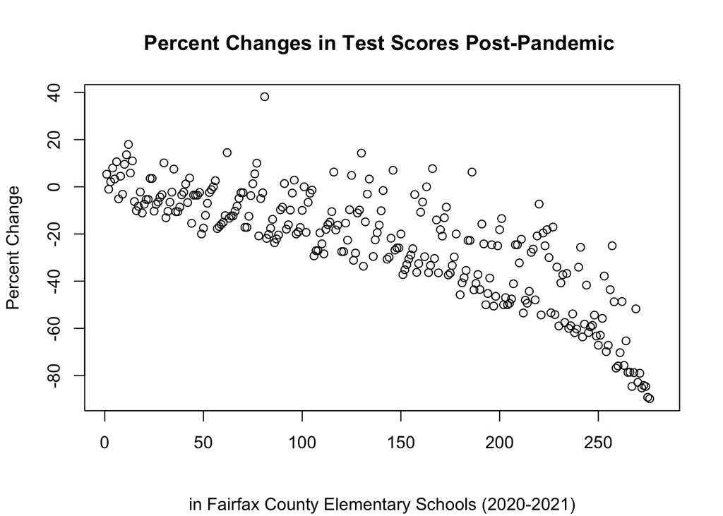

```r
# simple plot
plot(x = fair_elem_gr3_test_scores$pct_change, main = "Percent Changes in Test Scores Post-Pandemic ", sub = "in Fairfax County Elementary Schools (2020-2021)", ylab = "Percent Change", xlab = "")
```

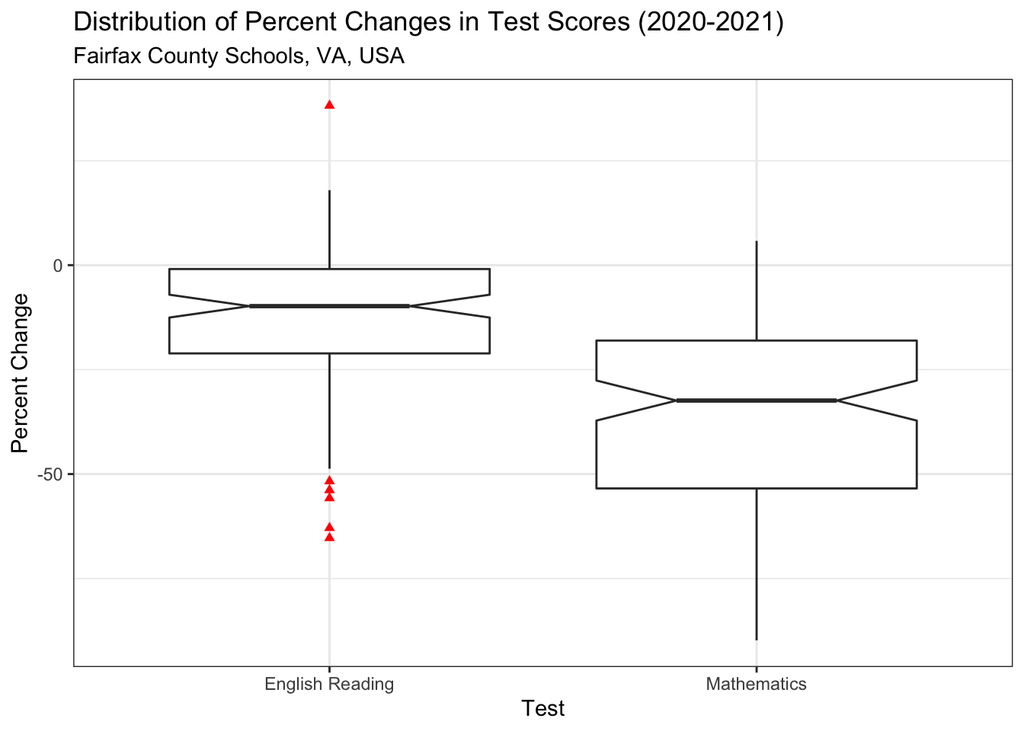

```r
# distribution of percent change in test scores
ggplot(data = fair_elem_gr3_test_scores,
       aes(x = Test, y = pct_change)) +
  geom_boxplot(outlier.shape = "triangle", outlier.color = "red", notch = TRUE) +
  ggtitle("Distribution of Percent Changes in Test Scores (2020-2021)", subtitle = "Fairfax County Schools, VA, USA") +
  ylab("Percent Change") +
  theme_bw()
```

### Histogram of Test Scores by Test Subject

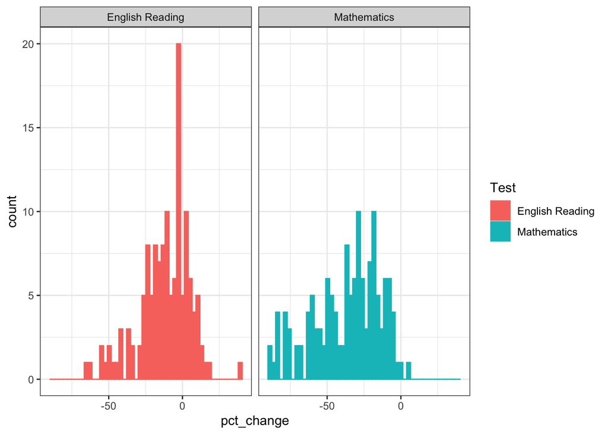

```r
# Histogram Views of Test Score Distributions by Test Subject
fair_elem_gr3_test_scores %>%
  ggplot(aes(x = pct_change, color = Test, fill = Test)) +
  geom_histogram(bins = 50) +
  facet_wrap(~Test) +
  theme_bw()
```

# Where are these schools geographically?

This [site](https://stackoverflow.com/questions/9068941/obtain-latitude-and-longitude-from-address-without-the-use-of-google-api) was helpful in deciding how to proceed to find a way to map the locations of schools from public data.

The Virginia Department of Education publishes school addresses on its website [here](https://www.doe.virginia.gov/directories/index.shtml)

```r
# public data from Virginia Dept of Education
va_schools_addresses <- read_csv("../data/Public_School_report.csv", skip = 2)
```

```
## ──────────────────────────────────────────────────────── Delimiter: "," chr
## (18): Division Name, School Name, Low Grades, High Grades, Division D... dbl
## (3): Division Num, NCES School Num, School Num
```

```r
# selecting only the columns needed
va_schools_addresses %>%
  select(`Division Name` , `School Name`, `Grade  Standard`, Address1:Zip) -> va_schools_addresses

# tidying columns and creating one full address because geocode() requires this for finding latutude and longitude of a given address
va_schools_addresses %>%
  rename(va_school_name = `School Name`) %>%
  filter(str_detect(`Division Name`, "Fairfax")) -> fairfax_school_addresses
```

### Joining Test Score Data with Address Data

```r
# joining the addresses df with the test score df
# note how the different joins can filter the rows of data
# an inner_join is the best option
fair_elem_gr3_test_scores %>% # 280 rows
  arrange(`Sch Name`) %>%
  # semi = return all rows in first df with a match in 2nd df without columns in 2nd
  # inner = return rows in x and y with columns from y === USE THIS ONE
  inner_join(fairfax_school_addresses, by = c(`Sch Name`= "va_school_name")) -> fair_elem_gr3_test_scores # correct 280 rows
```

### Using `ggmap` and Google Geocode API

#### Important:

To use the `ggmap` library, as shown below, please read and review the terms of obtaining a Google Geocode API key [here](https://developers.google.com/maps/documentation/geocoding/get-api-key#:~:text=Go%20to%20the%20Google%20Maps%20Platform%20%3E%20Credentials%20page.&text=On%20the%20Credentials%20page%2C%20click,Click%20Close.)

Please also read through how the `ggmap` package requires a Google API key [here](https://cran.r-project.org/web/packages/ggmap/readme/README.html). Google API keys have limits of usage unless you pay for how many requests are run in your code; therefore, use caution and keep track of how many requests your Google API key is logging through the [Google Cloud Platform](https://cloud.google.com).

```r
library(ggmap)
library(keyring)


# setting the API key to be hidden with keyring package
# key_set("geo_google_api")

# following directions to initialize the API key in the ggmap library
# register_google(key = key_get("geo_google_api"))

# test - do not run unless you have an API key
#geocode("11375 Center Harbor Rd, Reston, VA 20194")
```

Useful site that helped in this analysis [here](https://stackoverflow.com/questions/158474/how-to-obtain-longitude-and-latitude-for-a-street-address-programmatically-and)

### Do not run commented out code unless you have your own API key from Google Cloud Platform.

Below is the code for translating the physical address of each school into a latitude and longitude in order to plot on a map (geocoding):

```r
# ## quick glimpse of the data
# fair_elem_gr3_test_scores %>% #glimpse

# ## creating one column of full address which is the main argument for the geocode() function
#   unite(col = "full_address", Address1, Address2, City, State, Zip, sep = " ") %>%
#   ## calling the API via ggmap library that now requires one to have already set up a Google Geocode API within Google Cloud Platform
#   mutate(point_coords = geocode(full_address)) -> full_add_fair_elem
#

# # writing results in rds file
# write_rds(full_add_fair_elem, "./full_add_fair_elem.rds")
```

### Re-importing API Call Results from .rds file

```r
# note: do not re-run analysis file as it will call API and may log
# too many requests under the free plan
# therefore the API call was run just once above, checked, and
# written in rds for re-importing here every time this .Rmd is run
full_add_fair_elem <- read_rds("../output/full_add_fair_elem.rds")

# results of the API call are a column of tibbles
# unnesting the column of tibbles from the API call
full_add_fair_elem %>% unnest(point_coords) -> ll_df

# checking
#ll_df
```

### Creating Popup Labels in Data Frame Before Mapping

```r
# renaming columns so that leaflet or other map library recognizes them as latitude and longitude
ll_df %>%
  mutate(latitude = lat,
         longtitude = lon) -> ll_df

# writing finished file
write_rds(ll_df, "../output/ll_df.rds")

# using finished file from this point forward to map
ll_df <- read_rds("../output/ll_df.rds")

# creating popup label
ll_df %>%
  mutate(popup_label = paste(paste0('<b>School Name: ', `Sch Name`, '</b>'),
                             paste0('Address: ', full_address),
                             sep = '<br/>')) -> ll_df


# checking data type before mapping
typeof(ll_df)
```

```
## [1] "list"
```

### Building the Map in Leaflet

For more information on how to build interactive maps in `leaflet`, please visit this [site](https://leafletjs.com).

```r
library(leaflet)

leaflet(data = ll_df) %>%
  addTiles() %>%
  setView(lng = -77.20, lat = 38.85, zoom = 10) %>%
  addCircleMarkers(lng = ll_df$longtitude,
                   lat = ll_df$latitude ,
                   popup = ~popup_label,
                   stroke=F,
                   radius = 4,
                   fillColor = "gray",
                   fillOpacity = 1)
```

[interactive chart not shown]

### Where are the schools that did not have more than a -5 % change post-pandemic?

```r
# filtering out schools that decreased in test score more than 5 % post-pandemic
ll_df %>%
  filter(pct_change>=-5) -> top_ll_df # 61 rows

# showing top 5 schools per test subject
# note: only 4 show up for math
top_ll_df %>%
  arrange(-pct_change) %>%
  summarise(`Sch Name`, Test, pct_change) %>%
  group_by(Test) %>%
  slice_max(pct_change, n=5)
```

```
## # A tibble: 9 × 3
## # Groups:   Test [2]
##   `Sch Name`                  Test            pct_change
##   <chr>                       <fct>                <dbl>
## 1 Cunningham Park Elementary  English Reading      38.2
## 2 West Springfield Elementary English Reading      17.9
## 3 Olde Creek Elementary       English Reading      14.5
## 4 Belle View Elementary       English Reading      14.3
## 5 Vienna Elementary           English Reading      13.6
## 6 Clermont Elementary         Mathematics           5.81
## 7 Haycock Elementary          Mathematics          -1.03
## 8 Fairfax Villa Elementary    Mathematics          -2.5
## 9 Floris Elementary           Mathematics          -4.40
```

# Revised Map of Schools

Goal: To see where the top performers are located in terms of district area within Fairfax County

```r
library(leaflet)

leaflet(data = top_ll_df) %>%
  addTiles() %>%
  setView(lng = -77.20, lat = 38.85, zoom = 10) %>%
  addCircleMarkers(lng = top_ll_df$longtitude,
                   lat = top_ll_df$latitude ,
                   popup = ~popup_label,
                   stroke=F,
                   radius = 4,
                   fillColor = "gray",
                   fillOpacity = 1)
```

[interactive chart not shown]

Citation for use of `ggmap` with Google Geocode API:

D. Kahle and H. Wickham. ggmap: Spatial Visualization with ggplot2. The R Journal, 5(1), 144-161. URL http://journal.r-project.org/archive/2013-1/kahle-wickham.pdf